# **Final Tutorial:**

# **Milestone Two -- Working with the Weather Dataset**

Working towards our ultimate goal of creating a model which can predict flight delays, we plan to incorporate a second dataset that tracks weather patterns over the same period of time. By ascribing the relevant weather events to flights that left at the same time at the same airport that reported it, we can dig deeper into the "flight delay" metric of our first dataset and identify root causes for why a delay may be caused.

```python
weather_df = pd.read_csv('/content/drive/MyDrive/WeatherEvents_Jan2016-Dec2022.csv') #Loading in our dataset.
weather_df.head()
```

|  | EventId | Type | Severity | StartTime(UTC) | EndTime(UTC) | Precipitation(in) | TimeZone | AirportCode | LocationLat | LocationLng | City | County | State | ZipCode |
| --- | --- | --- | --- | --- | --- | --- | --- | --- | --- | --- | --- | --- | --- | --- |
| 0 | W-1 | Snow | Light | 2016-01-06 23:14:00 | 2016-01-07 00:34:00 | 0.00 | US/Mountain | K04V | 38.0972 | -106.1689 | Saguache | Saguache | CO | 81149.0 |
| 1 | W-2 | Snow | Light | 2016-01-07 04:14:00 | 2016-01-07 04:54:00 | 0.00 | US/Mountain | K04V | 38.0972 | -106.1689 | Saguache | Saguache | CO | 81149.0 |
| 2 | W-3 | Snow | Light | 2016-01-07 05:54:00 | 2016-01-07 15:34:00 | 0.03 | US/Mountain | K04V | 38.0972 | -106.1689 | Saguache | Saguache | CO | 81149.0 |
| 3 | W-4 | Snow | Light | 2016-01-08 05:34:00 | 2016-01-08 05:54:00 | 0.00 | US/Mountain | K04V | 38.0972 | -106.1689 | Saguache | Saguache | CO | 81149.0 |
| 4 | W-5 | Snow | Light | 2016-01-08 13:54:00 | 2016-01-08 15:54:00 | 0.00 | US/Mountain | K04V | 38.0972 | -106.1689 | Saguache | Saguache | CO | 81149.0 |

```python
#First we must clean our data for merging. given that the processing time of colab does not effectively run through 3 million and 4.9 million data point merges.
# We will create "state" signifiers for our original dataframe, and a "year" signifier for both dataframes that can be used to merge our datasets.
weather_df['Flight Date'] = weather_df['StartTime(UTC)'].astype(str).str.slice(0, 10)
df['Origin State'] = df['Origin City'].str.split(', ')
df['Origin State'] = df['Origin State'].astype(str).str.slice(-4,-2)
df['Destination State'] = df['Destination City'].str.split(', ')
df['Destination State'] = df['Destination State'].astype(str).str.slice(-4,-2)
transpose_weather_df = weather_df[['EventId', 'Type','Severity', 'Flight Date','Precipitation(in)','State']]
transpose_weather_df['Year'] = transpose_weather_df['Flight Date'].str.slice(0,4)
merge_weather_df = transpose_weather_df[transpose_weather_df['Year'].astype(int) >= 2019] # Here we take only the relevent data -- 2019 or newer, which works with our other dataset.
```

```python
severity_order = {'Severe': 1, 'Heavy': 2, 'Moderate': 3, 'Light': 4, 'Other': 5, 'UNK': 6} # Here we create a priority order for severity to compress data.
# We need to do this because the amount of data we have forces google colab to regularly crash, so in order to follow tidy data principles we must compress the weather types.

def combine_types(types): # Here we create our combine function.
    return ', '.join(sorted(set(types)))

def highest_severity(severities): # Here is his severity sorting function.
    return min(severities, key=lambda x: severity_order.get(x, float('inf')))
```

```python
result_df = merge_weather_df.groupby(['Flight Date', 'State']).agg({ # Here we compress our dataframe properly by using our above features, but we take the first/greatest available data point
# for year, event, and precipitation, so we can keep the relevant precipitation data whilst compressing the other data.
    'Type': combine_types,
    'Severity': highest_severity,
    'Year': 'first',
    'EventId': 'first',
    'Precipitation(in)': 'max'
}).reset_index()
```

```python
merged_df = pd.merge(df, result_df, left_on=['Flight Date', 'Origin State'], right_on=['Flight Date', 'State'], how='left') # Now we merge our two dataframes on date and state of origin.
```

```python
merged_df['Precipitation(in)'] = merged_df['Precipitation(in)'].fillna(0.00) #Here we tidy our now combined dataframe, filling empty precipitation, type, and severity columns.
merged_df['Type'] = merged_df['Type'].fillna('None')
merged_df['Severity'] = merged_df['Severity'].fillna('None')
merged_df.drop(columns=['State', "EventId"], inplace = True) # We also drop irrelevant columns used for merging.
```

Now that we have merged our datasets, we can explore the newly merged weather data and find potential correlations to flight delays.

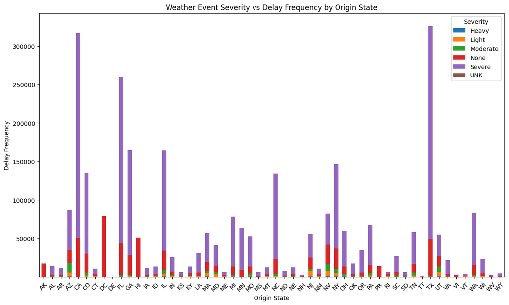

```python
# To analyze severity, we group data by 'Origin State' and 'Severity', counting the frequency of delays.
delay_counts = merged_df.groupby(['Origin State', 'Severity']).size().unstack(fill_value=0)

# Plotting our delay frequency.
delay_counts.plot(kind='bar', stacked=True, figsize=(14, 8))
plt.title('Weather Event Severity vs Delay Frequency by Origin State')
plt.xlabel('Origin State')
plt.ylabel('Delay Frequency')
plt.legend(title='Severity')
plt.xticks(rotation=45)
plt.show()
```

Displays the frequency of delays by severity level (Heavy, Moderate, Light, None, Severe, Unknown) across various origin states. This shows how often delays occur with different severities in each state.

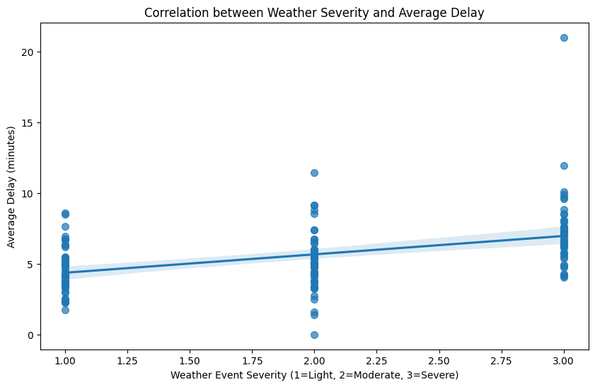

```
Correlation between weather severity and delay: 0.44
```

```python
from sklearn.linear_model import LinearRegression

# Next, we are going to look at weather severity and map it to numerical values to categorically compare this to numerical values.
severity_mapping = {'Severe': 3, 'Moderate': 2, 'Light': 1}
merged_df['Severity_Num'] = merged_df['Severity'].map(severity_mapping)

# Now we can remove  rows with missing delay values and calculate total delay by summing different types of delay columns to get total delay
delay_columns = ['Delay Due To Nas', 'Delay Due To Security', 'Delay Due To Late Aircraft']
merged_df['Total_Delay'] = merged_df[delay_columns].sum(axis=1, skipna=True)

# Now we will group by Origin State and quantitative Severity and calculate the average delay
delay_data = merged_df.groupby(['Origin State', 'Severity_Num']).agg({'Total_Delay': 'mean'}).reset_index()

# Plot our data
plt.figure(figsize=(10, 6))
sns.regplot(x='Severity_Num', y='Total_Delay', data=delay_data, scatter_kws={'s': 50, 'alpha': 0.7})
plt.title('Correlation between Weather Severity and Average Delay')
plt.xlabel('Weather Event Severity (1=Light, 2=Moderate, 3=Severe)')
plt.ylabel('Average Delay (minutes)')
plt.show()

# For additional data, we can also calculate correlation.
correlation = delay_data['Severity_Num'].corr(delay_data['Total_Delay'])
print(f"Correlation between weather severity and delay: {correlation:.2f}")
```

This shows the relationship between weather event severity (mapped numerically from Light = 1 to Severe = 3) and average delay in minutes, with a regression line. It indicates a positive but weak correlation between higher severity and longer delays. Potentially, once we remove some outliars and add in additional features, this could make up the basis of our model.

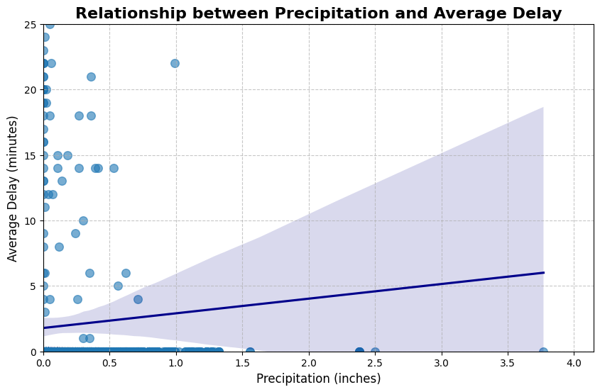

```
Correlation between precipitation and delay: 0.01
```

```python
# Now that we know there is a non-zero correlation between weather severity and delay, we can look for other correlations, for example precipitation

rain_only = merged_df.loc[merged_df['Type'] == 'Rain'] # Here we create a dataframe where only rain is a weather effect.
plt.figure(figsize=(10, 6))

# Using seaborne, create a scatter plot with regression to analyze precipitation
sns.regplot(
    x='Precipitation(in)', y='Delay Due To Weather', data=rain_only,
    scatter_kws={'s': 70, 'alpha': 0.6}, line_kws={'color': 'darkblue'}
)

# We plot our data here
plt.title('Relationship between Precipitation and Average Delay', fontsize=16, weight='bold')
plt.xlabel('Precipitation (inches)', fontsize=12)
plt.ylabel('Average Delay (minutes)', fontsize=12)
plt.ylim(0, 25)  # Set y axis and x axis limit to focus on relevant range of data
plt.xlim(0, rain_only['Precipitation(in)'].max() * 1.1)
plt.xticks(fontsize=10)
plt.yticks(fontsize=10)
plt.grid(True, linestyle='--', alpha=0.7)

# Show plot
plt.show()

# Again, we can calculate the correlation coefficient for more insight!
correlation_precip = rain_only['Precipitation(in)'].corr(rain_only['Delay Due To Weather'])
print(f"Correlation between precipitation and delay: {correlation_precip:.2f}")
```

Depicts the relationship between precipitation (in inches) and average delay in minutes with a regression line. The correlation is minimal, suggesting precipitation alone is not strongly linked to delay duration. This is likely due to the advancements in modern flight technology and air traffic control that allow flights to take off in rainy conditions.

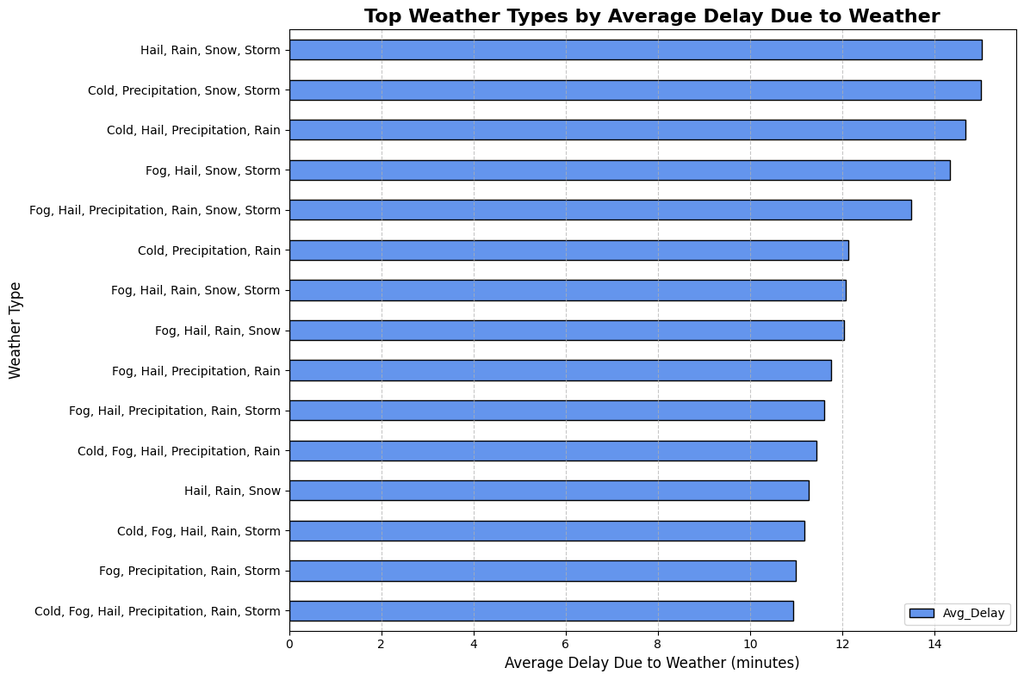

```python
# Sort the data by average delay and select the top 15 weather types with the highest delays
avg_weather_delay = merged_df.groupby('Type')['Total_Delay'].mean().reset_index()
avg_weather_delay.columns = ['Type', 'Avg_Delay']
top_avg_weather_delay = avg_weather_delay.sort_values(by='Avg_Delay', ascending=False).head(15)

# Plotting
plt.figure(figsize=(12, 8))
top_avg_weather_delay.plot(kind='barh', x='Type', y='Avg_Delay', color='cornflowerblue', edgecolor='black', figsize=(12, 8))

# Improve plot aesthetics
plt.title('Top Weather Types by Average Delay Due to Weather', fontsize=16, weight='bold')
plt.xlabel('Average Delay Due to Weather (minutes)', fontsize=12)
plt.ylabel('Weather Type', fontsize=12)
plt.gca().invert_yaxis()  # Invert y-axis to have the highest delays at the top
plt.grid(axis='x', linestyle='--', alpha=0.7)
plt.xticks(fontsize=10)
plt.yticks(fontsize=10)

# Show plot
plt.tight_layout()
plt.show()
```

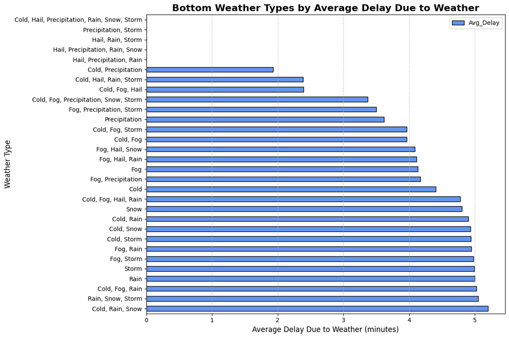

```python
# Sort the data by average delay and select the top 30 weather types with the lowest delays
bottom_avg_weather_delay = avg_weather_delay.sort_values(by='Avg_Delay', ascending=True).head(30)

# Plotting
plt.figure(figsize=(12, 8))
bottom_avg_weather_delay.plot(kind='barh', x='Type', y='Avg_Delay', color='cornflowerblue', edgecolor='black', figsize=(12, 8))

# Improve plot aesthetics
plt.title('Bottom Weather Types by Average Delay Due to Weather', fontsize=16, weight='bold')
plt.xlabel('Average Delay Due to Weather (minutes)', fontsize=12)
plt.ylabel('Weather Type', fontsize=12)
plt.gca().invert_yaxis()  # Invert y-axis to have the highest delays at the top
plt.grid(axis='x', linestyle='--', alpha=0.7)
plt.xticks(fontsize=10)
plt.yticks(fontsize=10)

# Show plot
plt.tight_layout()
plt.show()
```

Comparing the two, we can see all of the parameters with little to no complications, as expected lead to very little delays. As one would expect, when looking at these 30 versus the top 15 delays, this graph expressed very few weather conditions with more than three cumulative conditions that day.

# Plausible Models

1. **Weather Severity Model**: The graphs above answered our earlier reservations about weather type and severity, and defends the assumption that the weather model is worth exploring.
   - **Objective**: To predict the average delay time based on weather severity.
   - **Independent Variable**: Weather severity level (categorized as Light, Moderate, Heavy, Severe).
   - **Dependent Variable**: Average delay time in minutes.
   - **Methodology**: A regression model could be applied, using severity levels as input to quantify the impact of different severity categories on delay times. The correlation observed in the EDA section supports this model, showing that higher severity is associated with longer delays. Outliers may be removed to enhance model accuracy, and additional features (like location or specific weather types) could be incorporated for a more nuanced model.
2. **Airline Airport Impact Model**: Some of the highest correlations that we've experienced come from Airline and Airport metrics, and we proved from the Airline Performance Graph that airlines with frequent delays also have longer delays, meaning that if we are able to predict based on airline, we may be able to separate out the longest delay types.
   - **Objective**: To examine the influence of situational factors such as Airline and Airport on delay duration specifically related to weather.
   - **Independent Variables**: Airline, Airport, Date, Month.
   - **Dependent Variable**: Average delay time in minutes.
   - **Methodology**: This model would use linear regression to predict the likelihood of a delay based on circumstantial factors of an individual flight. The EDA indicates minimal correlation between certain weather patterns such as precipitation alone and delay, potentially due to modern aviation adaptations. However, certain holiday seasons and weekends tend to have more flight delays. In order to track the variability of these delays, we will use these features to separate out the worst managed and best managed airlines, potentially catching the delays due to non-weather factors as well.

These observations may form the base of our model, but we may combine them and utilize other features of our data, such as origin city to create a multifaceted and more successful model!

```python
ordinal_encoder = OrdinalEncoder() # This is an encoder, used for converting categorical features in our dataset.

merged_df['Delay Due To Weather'].fillna(0.0, inplace = True) # Here we fillna to ensure we can utilize our delay data, as there are some unreported NA values.

sample_df = merged_df[merged_df['Delay Due To Weather'] > 0.0] # Here we take a sample of only values where delays exist, to properly test our data.
sample_df = sample_df.sample(n=500) # We want a sample of 500 rather than the entire set, as working with millions of data points exceeds the COLAB available ram.
```

```python
encoded_columns = ordinal_encoder.fit_transform(sample_df[['Origin Airport', 'Type', 'Airline Name', 'Severity']]) # Using fit transform we will encode our categorical features into:
sample_df[['Airport_Encoded', 'Type_Encoded', 'Airline_Encoded', 'Severity_Encoded']] = encoded_columns # "Encoded" versions of the features to use in our model.

dummy_features = sample_df[['Airport_Encoded', "Type_Encoded", "Airline_Encoded", "Severity_Encoded"]] # Ascribe these encoded or "dummy features" for concatenation
```

```python
merged_select = pd.concat([sample_df, dummy_features], axis=1) # Take the dummy features and merge them with the other features to make up our model.
```

Before we create a final linear regression model, reviewing some of the now encoded features for correlations with Weather Based Delay and Total Delay will help us identify how valuable, if at all, these features are to contributing to overall model success

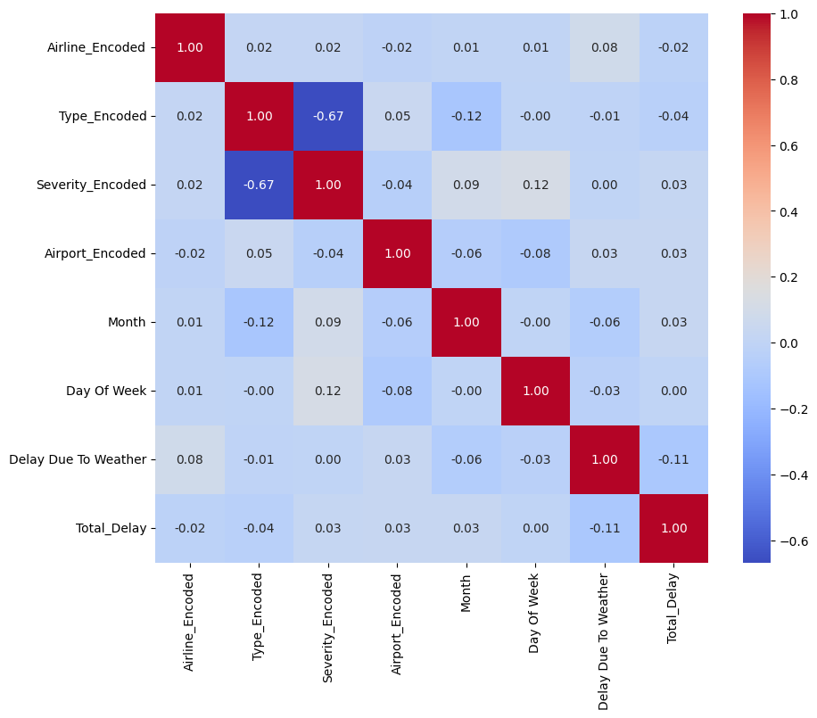

```python
X2 = merged_select[['Airline_Encoded','Type_Encoded', 'Severity_Encoded', 'Airport_Encoded', 'Month','Day Of Week', 'Delay Due To Weather', 'Total_Delay']] #We will take another set of features here for our correlation matrix, so we can view
X2 = X2.loc[:, ~X2.columns.duplicated()] # multiple relationships between the data features in one graph.

correlation_matrix = X2.corr() # Here we can create a correlation matrix, which we can plot in subsequent lines to give a visual indicator of feature correlation.

# Plot heatmap of the correlation matrix.
plt.figure(figsize=(10, 8))
sns.heatmap(correlation_matrix, annot=True, cmap='coolwarm', fmt='.2f')
plt.show()
```

```python
X = merged_select[['Month','Day Of Week', 'Severity_Encoded', 'Delay Due To Weather']] #Identify our features and fill NA values.
X.fillna(0, inplace=True)

# Identify the target variable and split the dataset into training and testing sets.
y = sample_df['Total_Delay']
X_train, X_test, y_train, y_test = train_test_split(X, y, test_size=0.2, random_state=42)

# Initialize and train the linear regression model.
model = LinearRegression()
model.fit(X_train, y_train)

# Make predictions on the test set, calculate y_prediction output.
y_pred = model.predict(X_test)
```

```python
results = pd.DataFrame({'Actual': y_test, 'Predicted': y_pred}) # Using the y_test and y_predicted values, we can find our discrepancies between the actual values we tested on and the predicted values.
print(results.head())
correlation = np.corrcoef(y_test, y_pred)[0, 1] # Printing the correlation shows the outputs of our model.
print("Correlation between Actual and Predicted:", correlation)
```

```
         Actual  Predicted
1001450     0.0  23.930062
2721235     6.0  38.190434
2889622     0.0  37.284423
1445644   207.0  39.999350
2967670    19.0  33.902876
Correlation between Actual and Predicted: 0.1674945907686122
```

### **Flight Delays Decoded: Insights and Future Directions**

Our deep dive into flight delays revealed a complex landscape of factors that influence travel disruptions. Through innovative data visualization and analysis, we uncovered some surprising patterns that challenge traditional assumptions about what causes flight delays.

**What We Discovered**

The journey began with an exploration of potential delay triggers, examining everything from weather conditions to airline-specific performance. Our findings paint a nuanced picture:

**Looking Forward: Smarter Delay Prediction**

One critical observation from our tutorial is that when testing, focusing only on delayed flights exaggerates delay durations in the model, skewing predictions when applied to the entire dataset. Conversely, including all flights dilutes the model's sensitivity to factors that predict delays. Balancing these inputs was a challenge of this tutorial and refining this would be a highly beneficial next step forward.

Future steps should consider combining weather-related features like severity, precipitation, and location data to enhance predictions. Additionally, implementing non-linear modeling methods may better capture complex interactions that our linear regression model failed to address, such as those between airline-specific performance (Figure: Delay Frequency vs. Average Delay Length) and weather conditions. By addressing these limitations, the model can better predict flight delays with accuracy and contextual relevance.

- **Non Linear Modeling**: By embracing techniques like KNN, Random Forests and Decision Trees, we can capture the impacts of certain features pertaining to flight delays that this linear model may have missed.
- **Other Data Strategies**: Further Data Analysis and real time datasets (found at the top of the tutorial) may afford us new insights into these features. By understanding the reasoning behind currently hidden factors that cause delays, we can create a model that makes travel easier.

**The Road Ahead** For anyone using this tutorial, the best next step would be to look at additional model types and different features! Refer to the top of this tutorial for links for further exploration, inlcuding real-time datasets and different model concepts, including K-Nearest Neighbors.